# Praca domowa nr 5

Wojciech Bogucki

20 listopada 2018

# Problemy z odczytywaniem danych na wykresach

## Opis eksperymentu

W ramach eksperymentu przeprowadziłem ankietę ([link](https://goo.gl/forms/2S8KX4qLs5h5WuuI2)) na grupie 16 osób. Ankieta zawierała 6 pytań sprawdzających:

- Z którego wykresu łatwiej odczytać dane - kołowego czy słupkowego?
- Czy iluzje optyczne utrudniają odczytywanie danych?
- Co jest lepsze do przedstawienia trójwymiarowych danych - słupki z kolorami czy punkty z podpisam?

Dane zostały wymyślone na potrzeby wizualizacji.

## Wykres kołowy vs wykres słupkowy

Pierwsze pytanie sprawdzało czy łatwo jest odczytać dane z wykresu kołowego. Uczystnicy mieli wskazać bank mający największy wycinek koła.

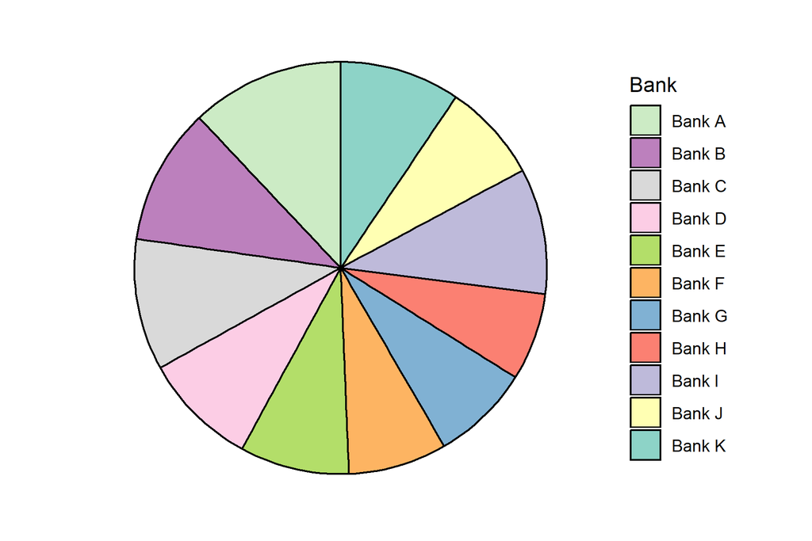

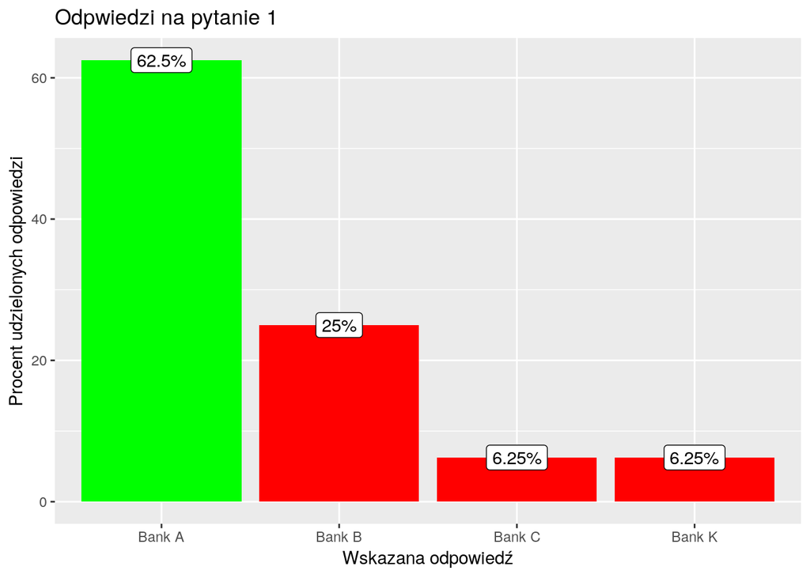

## Iluzje optyczne - czy warto używać kolorów?

W pytanu 3. poproiłem ankietowanych o stwierdzenie czy trzy wskazane banki (B, E, G) mają takie samo oprocentowanie, które zostało zakodowane na wykresie za pomocą kolorów - im jaśniejszy tym wyższe oprocenowanie.

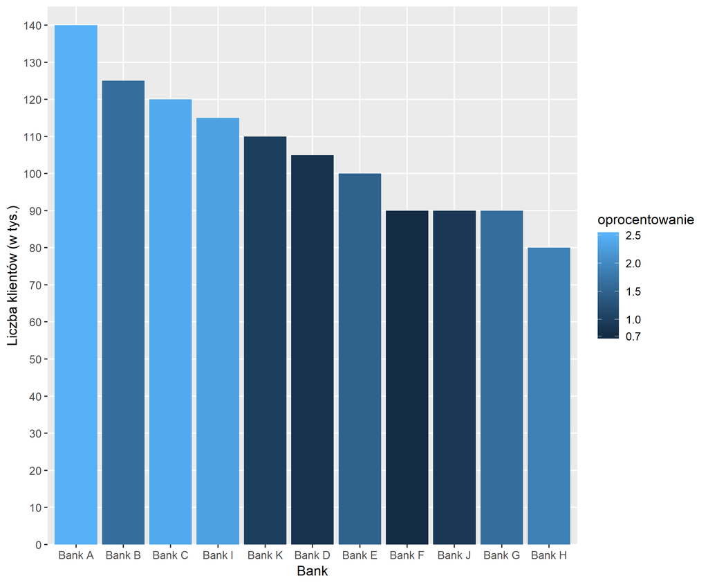

Bank E miał oprocentowanie na poziomie 1.5, a dwa pozostałe 1.65:

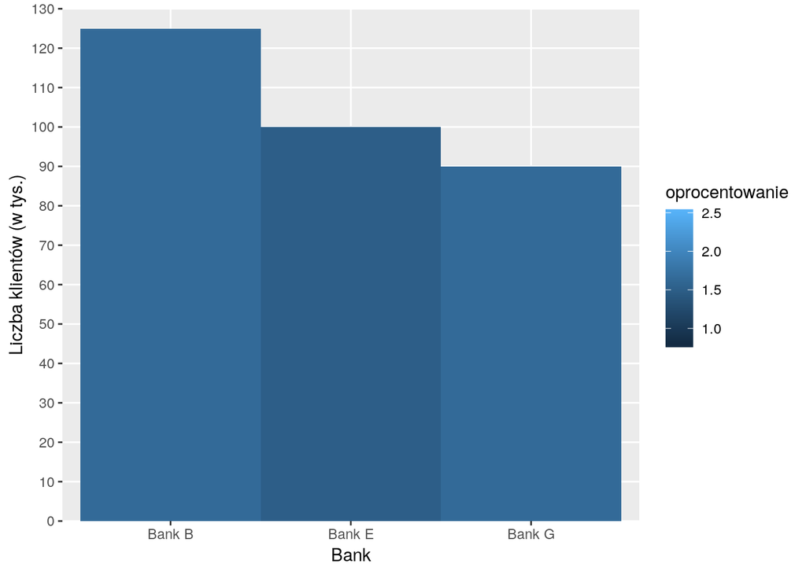

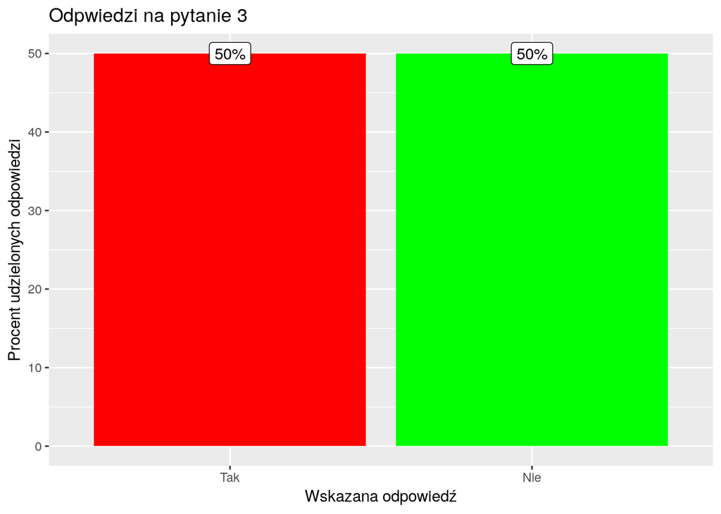

Aż 50% ankietowanych uległo złudzeniu optycznemu i wskazało złą odpowiedź.

Następne pytanie było już bardziej szczegółowe - pytałem o to który z omawianych trzech banków ma niższe oprocentowanie.

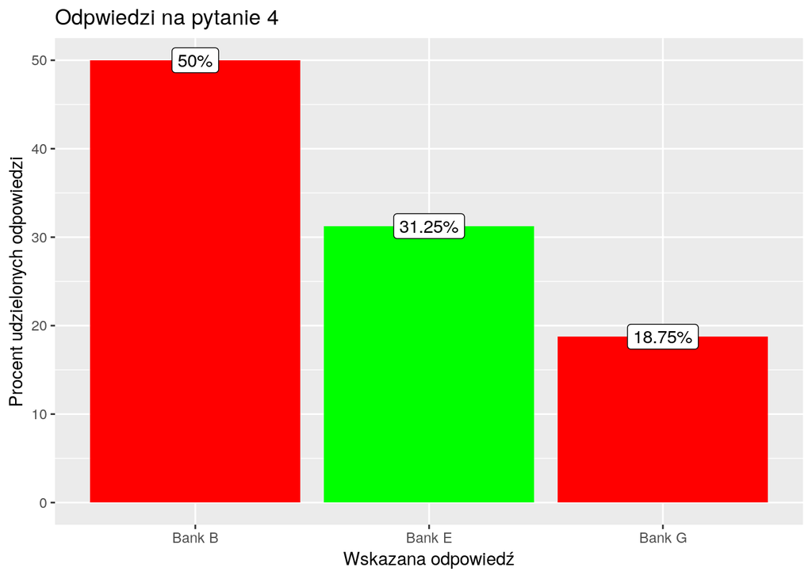

Tym razem już tylko 31,3% osób odpowiedziało poprawnie. Wynikać to mogło z faktu, iż bank E był w sąsiedztwie banków o niższym oprocentowaniu i jego delikatnie ciemniejszy słupe nie wyróżniał się obok jeszcze ciemniejszyh sąsiadów. Natomiast bank B był obok banków o jasnych słupkach, co mogło dać wrażenie, że jest on trochę ciemniejszy. **Wniosek:** używanie kolorów do kodowania zbliżonych wartości może prowadzić do błędów w odczytaniu danych, spowodowanych np. iluzją optyczną.

## Co innego zamiast kolorów?

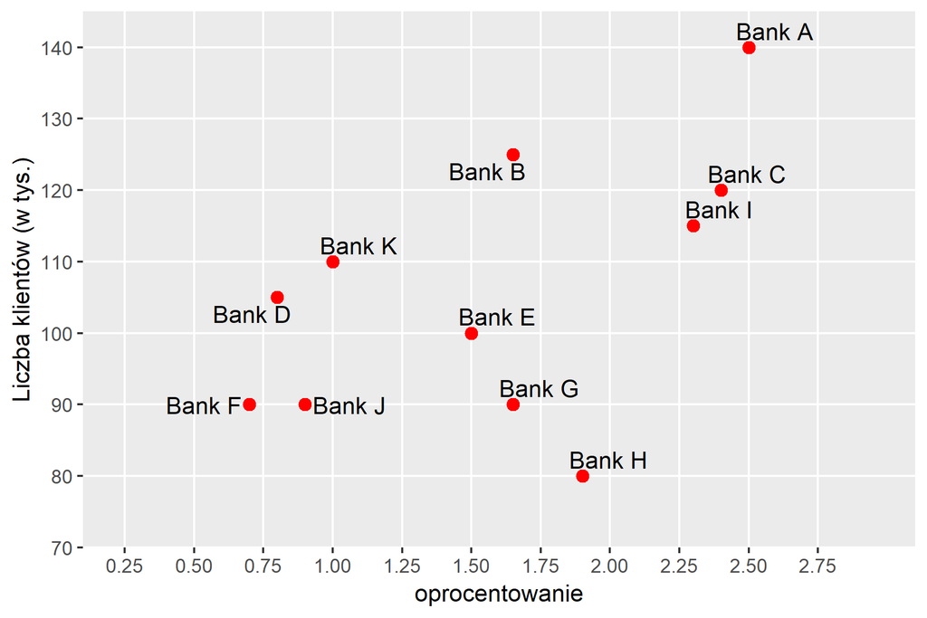

Ponownie zapytałem ankietowanych o to, który z podanych trzech banków ma najniższe oprocentowanie.

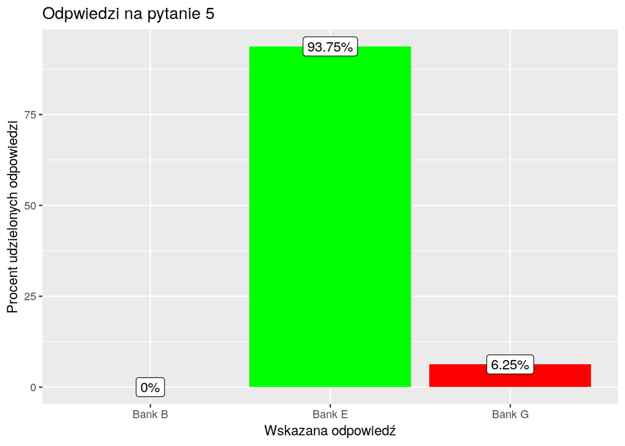

Tym razem 15 z 16 odpowiedzi(93,8%) było poprawnych. **Wniosek:** wykres punktowy z podpisami lepiej przedstawia dane trójwymiarowa niż wykres słupkowy z kolorami.

## Podsumowanie

Mimo że ankieta była przeprowadzona na małej liczbie osób, wyniki pokazały, że omawiane “dobre praktyki” faktycznie wpływają na czytelność wykresów i efektywność przekazywania informacji.